# Data Analysis

Normality Testing, Descriptive Statistics, Parametric and Non-Parametric Tests

Workshop

## Setup

```r
library(tidyverse)
library(readxl)
library(janitor)
library(nortest)
library(car)
library(rstatix)
library(exact2x2)

p <- read_excel("../data/prac_modded.xlsx") |>
  clean_names()
```

# Why Data Analysis Matters

## Importance of Data Analysis

**Making Sense of Data**

- **Driving Informed Decisions** — strategic choices based on evidence, not intuition
- **Identifying Patterns and Insights** — uncovering hidden relationships in data
- **Optimizing Processes** — streamline operations using performance metrics
- **Supporting Innovation** — fuel new ideas and solutions

**Research Perspective**

- **Evidence-Based Research** — validate hypotheses and draw reliable conclusions
- **Mitigating Risk** — identify potential errors before they reach conclusions
- **Improving Reproducibility** — ensures findings can be replicated
- **Ethical Responsibility** — especially critical in clinical and health research

# Choosing the Right Statistical Test

## Why Test Selection Matters

Choosing the wrong test leads to **Type I** (false positive) or **Type II** (false negative) errors.

| Reason | Detail |
| --- | --- |
| Accuracy & Validity | Test must match data nature and research question |
| Avoiding Errors | Wrong test → misleading conclusions |
| Reproducibility | Correct test ensures others can replicate findings |
| Meeting Objectives | Test must align with the hypothesis |
| Ethical Responsibility | In clinical research, conclusions affect real policy |

## Decision Framework — Overview

> The choice of statistical test depends on: **variable type → number of groups → normality → independence of observations**

**Note**

# Variables

## Types of Variables

**Note**

**Categorical / Qualitative**

- **Nominal** — no order (e.g., sex, past history of DM)
- **Ordinal** — ordered categories (e.g., wealth index: poorest → richest)
- **Binary / Dichotomous** — two categories (e.g., screened: Yes/No)

**Numerical / Quantitative**

- **Discrete** — whole numbers (e.g., number of visits)
- **Continuous** — any value in a range (e.g., age, SBP, height, FBS)

# Descriptive Statistics

## Categorical Variables — Frequency Tables

Use `table()` for base R frequency counts or `group_by()` + `reframe()` for tidy output.

```r
# Base R approach
freq_table <- table(p$past_history_of_diabetes)
prop_table <- prop.table(freq_table)

combined_table <- data.frame(
  Frequency = freq_table,
  Percentage = round(prop_table * 100, 2)
)
combined_table
```

```
  Frequency.Var1 Frequency.Freq Percentage.Var1 Percentage.Freq
1             no            597              no           94.61
2            yes             34             yes            5.39
```

## Categorical Variables — Tidyverse Approach

```r
# Frequency and percentage using dplyr — unordered factor
summary_table <- p %>%
  mutate(wealth_index = factor(wealth_index_of_participants)) |>
  group_by(wealth_index) %>%
  reframe(
    Frequency = n(),
    Percentage = paste(round(n() * 100 / nrow(p), 2), "%")
  )
summary_table
```

```
# A tibble: 5 × 3
  wealth_index Frequency Percentage
  <fct>            <int> <chr>
1 middle             147 23.3 %
2 poorer             106 16.8 %
3 poorest             34 5.39 %
4 richer             177 28.05 %
5 richest            167 26.47 %
```

## Categorical Variables — Ordered Factor

```r
# Define a meaningful order for wealth index
summary_table_1 <- p %>%
  mutate(wealth_index = factor(
    wealth_index_of_participants,
    levels = c("poorest", "poorer", "middle", "richer", "richest")
  )) |>
  group_by(wealth_index) %>%
  reframe(
    Frequency = n(),
    Percentage = paste(round(n() * 100 / nrow(p), 2), "%")
  )
summary_table_1
```

```
# A tibble: 5 × 3
  wealth_index Frequency Percentage
  <fct>            <int> <chr>
1 poorest             34 5.39 %
2 poorer             106 16.8 %
3 middle             147 23.3 %
4 richer             177 28.05 %
5 richest            167 26.47 %
```

## Continuous Variables — Summary Statistics

```r
# Base R
summary(p$age_of_participants)
```

```
   Min. 1st Qu.  Median    Mean 3rd Qu.    Max.
  18.00   29.00   42.00   43.85   58.00   95.00
```

```r
sd(p$age_of_participants)
```

```
[1] 17.36487
```

## Continuous Variables — Full Tidyverse Summary

```r
p |>
  summarise(
    mean_age    = mean(age_of_participants),
    sd_age      = sd(age_of_participants),
    median_age  = median(age_of_participants),
    Q1          = quantile(age_of_participants, 0.25),
    Q3          = quantile(age_of_participants, 0.75),
    IQR         = IQR(age_of_participants),
    var_age     = var(age_of_participants),
    min_age     = min(age_of_participants),
    max_age     = max(age_of_participants)
  )
```

```
# A tibble: 1 × 9
  mean_age sd_age median_age    Q1    Q3   IQR var_age min_age max_age
     <dbl>  <dbl>      <dbl> <dbl> <dbl> <dbl>   <dbl>   <dbl>   <dbl>
1     43.8   17.4         42    29    58    29    302.      18      95
```

# Normality Testing

## Why Check Normality?

Many parametric tests (t-test, ANOVA, Pearson’s r) **assume normally distributed data**.

Failing to check normality can lead to:

- Invalid p-values
- Wrong test selection
- Misleading conclusions

**Two approaches:** Visual methods + Statistical tests

## Visual Methods — Histogram

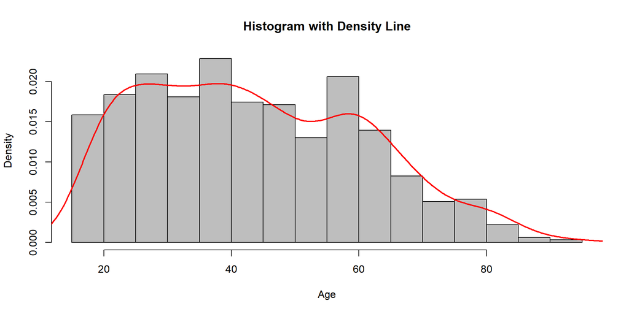

```r
hist(
  p$age_of_participants,
  main  = "Histogram with Density Line",
  xlab  = "Age",
  ylab  = "Density",
  col   = "grey",
  border = "black",
  freq  = FALSE
)
lines(density(p$age_of_participants), col = "red", lwd = 2)
```

*A roughly bell-shaped curve suggests normality. Skewed or multimodal histograms indicate non-normality.*

## Visual Methods — QQ Plot

```r
qqnorm(p$sbp_in_mm_hg, main = "Q-Q Plot: SBP")
qqline(p$sbp_in_mm_hg, col = "red")
```

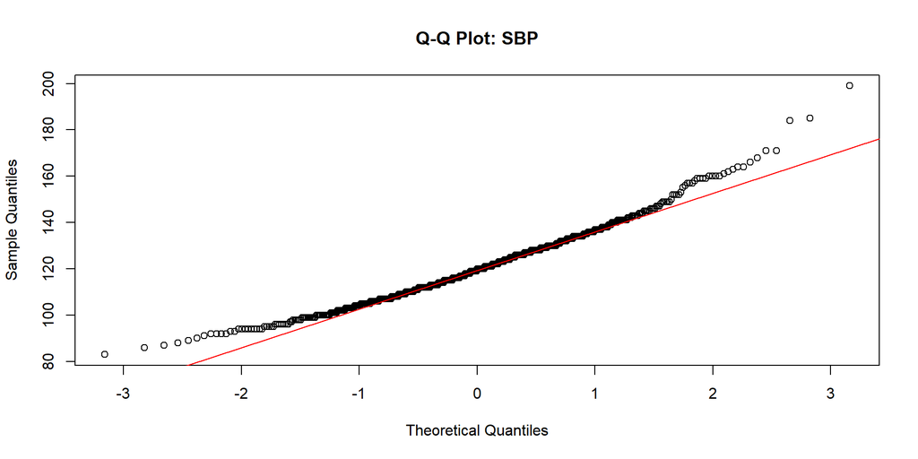

*Points should follow the red diagonal line closely if the data are normally distributed. Deviations at the tails indicate non-normality.*

## Statistical Tests — Shapiro-Wilk

Best for **small samples (n ≤ 50)**. Randomly sample if n > 50.

```r
p1 <- p[sample(nrow(p), 50), ]
s_test <- shapiro.test(p1$age_of_participants)
s_test
```

```
    Shapiro-Wilk normality test

data:  p1$age_of_participants
W = 0.95857, p-value = 0.07744
```

> **Interpretation:** p > 0.05 → data does not significantly deviate from normality (cannot reject H₀ of normality).

## Statistical Tests — Kolmogorov-Smirnov

Suitable for **larger samples**. Compares distribution to a theoretical normal.

```r
ks_test <- ks.test(p$sbp_in_mm_hg, "pnorm",
                   mean = mean(p$sbp_in_mm_hg),
                   sd   = sd(p$sbp_in_mm_hg))
ks_test
```

```
    Asymptotic one-sample Kolmogorov-Smirnov test

data:  p$sbp_in_mm_hg
D = 0.052082, p-value = 0.06522
alternative hypothesis: two-sided
```

> **Note:** Use `options(scipen = 999)` to display p-values in decimal format instead of scientific notation.

## Statistical Tests — Anderson-Darling

More sensitive to tails than KS test. Requires `nortest` package.

```r
ad_test <- ad.test(p$height)
ad_test
```

```
    Anderson-Darling normality test

data:  p$height
A = 0.27928, p-value = 0.6458
```

| Test | Best Use | Package |
| --- | --- | --- |
| Shapiro-Wilk | n ≤ 50 | base R |
| Kolmogorov-Smirnov | n > 50, continuous | base R |
| Anderson-Darling | Sensitive to tail deviations | `nortest` |

# Statistical Tests — Categorical Variables

## Chi-Square Goodness-of-Fit — 1 Group

Tests whether the observed distribution matches an **expected distribution**.

```r
observed <- table(p$ever_screened_for_bp)
total    <- sum(observed)
expected <- c(1/2, 1/2) * total

chisq_test <- chisq.test(x = observed, p = expected / sum(expected))
chisq_test
```

```
    Chi-squared test for given probabilities

data:  observed
X-squared = 80.23, df = 1, p-value < 2.2e-16
```

> **Assumption:** Expected frequency ≥ 5 in each cell.

## Chi-Square Test — 2 Binary Groups (Expected ≥ 5)

Tests association between two categorical variables using a **contingency table**.

```r
table_gender_dm <- table(p$sex_of_participants, p$past_history_of_diabetes)
table_gender_dm
```

```
          no yes
  female 332  17
  male   265  17
```

```r
chisq_m5 <- chisq.test(table_gender_dm, correct = FALSE)
chisq_m5
```

```
    Pearson's Chi-squared test

data:  table_gender_dm
X-squared = 0.40978, df = 1, p-value = 0.5221
```

```r
# Check expected frequencies
chisq_m5$expected
```

```
               no      yes
  female 330.1949 18.80507
  male   266.8051 15.19493
```

> Use `correct = FALSE` to apply the standard Pearson Chi-square (no Yates correction).

## Chi-Square — Yates Continuity Correction

Yates correction subtracts 0.5 from the absolute difference between observed and expected frequency before squaring.

```r
# With Yates correction (correct = TRUE is default for 2x2 tables)
chisq.test(table_gender_dm, correct = TRUE)
```

```
    Pearson's Chi-squared test with Yates' continuity correction

data:  table_gender_dm
X-squared = 0.2142, df = 1, p-value = 0.6435
```

> Apply when sample sizes are small or expected frequencies approach 5.

## When Expected Frequency < 5

Two options: **Monte Carlo simulation** or **Fisher’s Exact Test**.

```r
table_htn_dm <- table(p$ever_screened_for_bp, p$past_history_of_diabetes)

# Monte Carlo simulation (B = number of replicates, min p = 1/(B+1))
chisq_mc <- chisq.test(table_htn_dm, simulate.p.value = TRUE, B = 2000)
chisq_mc
```

```
    Pearson's Chi-squared test with simulated p-value (based on 2000
    replicates)

data:  table_htn_dm
X-squared = 11.381, df = NA, p-value = 0.002999
```

```r
# Fisher's Exact Test
fisher_test <- fisher.test(table_htn_dm)
fisher_test
```

```
    Fisher's Exact Test for Count Data

data:  table_htn_dm
p-value = 0.0002606
alternative hypothesis: true odds ratio is not equal to 1
95 percent confidence interval:
  2.032418 70.633884
sample estimates:
odds ratio
  8.105124
```

## Chi-Square — m × n Contingency Table

Use when both variables have **more than two categories**.

```r
table_mar_wealth <- table(
  p$marital_status_of_participants,
  p$wealth_index_of_participants
)
table_mar_wealth
```

```
                        middle poorer poorest richer richest
  currently married         82     68      17    119     115
  formerly/ever married     31     16      13     22      14
  never married             34     22       4     36      38
```

```r
chisq_mn <- chisq.test(table_mar_wealth)
chisq_mn
```

```
    Pearson's Chi-squared test

data:  table_mar_wealth
X-squared = 26.65, df = 8, p-value = 0.0008122
```

```r
# Monte Carlo if expected frequencies < 5
chisq_mn_mc <- chisq.test(table_mar_wealth, simulate.p.value = TRUE, B = 2000)
chisq_mn_mc
```

```
    Pearson's Chi-squared test with simulated p-value (based on 2000
    replicates)

data:  table_mar_wealth
X-squared = 26.65, df = NA, p-value = 0.002499
```

## McNemar Test — Paired Binary Responses

Use when the **same participants** are measured twice on a binary outcome (e.g., before and after treatment).

```r
table_bfr_aftr <- table(p$pain_foot_bfr, p$pain_foot_aftr)
table_bfr_aftr
```

```
       No Yes
  No  176 159
  Yes 150 146
```

```r
mcnemar_test <- mcnemar.test(table_bfr_aftr)
mcnemar_test
```

```
    McNemar's Chi-squared test with continuity correction

data:  table_bfr_aftr
McNemar's chi-squared = 0.20712, df = 1, p-value = 0.649
```

> **Assumption:** Discordant cells (b + c) should be ≥ 25. If < 25, use exact McNemar.

## Exact McNemar Test

```r
exact_mcnemar <- exact2x2::mcnemar.exact(table_bfr_aftr)
exact_mcnemar
```

```
    Exact McNemar test (with central confidence intervals)

data:  table_bfr_aftr
b = 159, c = 150, p-value = 0.6491
alternative hypothesis: true odds ratio is not equal to 1
95 percent confidence interval:
 0.8426767 1.3339030
sample estimates:
odds ratio
      1.06
```

[output not shown]

# Statistical Tests — Continuous Variables

## One Group — Z Test

Use when population SD is **known** and n > 30.

```r
pr  <- p |> filter(wealth_index_of_participants == "richer")
mu  <- mean(p$age_of_participants)
sigma <- sd(p$age_of_participants)

s_mean <- mean(pr$age_of_participants)
n      <- length(pr$age_of_participants)
z      <- (s_mean - mu) / (sigma / sqrt(n))

p_two_tailed     <- 2 * (1 - pnorm(abs(z)))
p_one_tailed_gt  <- 1 - pnorm(z)
p_one_tailed_lt  <- pnorm(z)

cat("Z =", round(z, 3),
    "\nTwo-tailed p =", round(p_two_tailed, 4),
    "\nOne-tailed (greater) p =", round(p_one_tailed_gt, 4))
```

```
Z = -0.879
Two-tailed p = 0.3794
One-tailed (greater) p = 0.8103
```

## One Group — One-Sample t Test

Use when population SD is **unknown** or n < 30.

```r
pp <- p |> filter(wealth_index_of_participants == "poorest")

t_test <- t.test(pp$age_of_participants, mu = mu)
t_test
```

```
    One Sample t-test

data:  pp$age_of_participants
t = 1.5716, df = 33, p-value = 0.1256
alternative hypothesis: true mean is not equal to 43.84786
95 percent confidence interval:
 42.28702 56.00709
sample estimates:
mean of x
 49.14706
```

| Test | Population SD | n |
| --- | --- | --- |
| One-sample Z | Known | > 30 |
| One-sample t | Unknown | Any; especially < 30 |

## Two Groups — Testing Equal Variance

Before an independent t-test, verify the **equal variance assumption**.

```r
# Levene's test (robust to non-normality)
car::leveneTest(weight ~ sex_of_participants, data = p)
```

```
Levene's Test for Homogeneity of Variance (center = median)
       Df F value Pr(>F)
group   1  0.0453 0.8316
      629
```

```r
# Bartlett's test (assumes normality)
bartlett.test(weight ~ sex_of_participants, data = p)
```

```
    Bartlett test of homogeneity of variances

data:  weight by sex_of_participants
Bartlett's K-squared = 0.21685, df = 1, p-value = 0.6415
```

> **Interpretation:** p < 0.05 → variances are NOT equal → use `var.equal = FALSE` in t.test.

## Two Groups — Independent t Test (Unpaired, Normal)

```r
ind_t_test <- t.test(weight ~ sex_of_participants,
                     var.equal = TRUE,
                     data = p)
ind_t_test
```

```
    Two Sample t-test

data:  weight by sex_of_participants
t = 0.61333, df = 629, p-value = 0.5399
alternative hypothesis: true difference in means between group female and group male is not equal to 0
95 percent confidence interval:
 -1.662463  3.172588
sample estimates:
mean in group female   mean in group male
            70.04272             69.28766
```

**Note**

## Two Groups — Paired t Test (Normal)

Use when the **same participants** are measured at two time points.

```r
paired_t_test <- t.test(p$fbs_presentation, p$fbs_6_months, paired = TRUE)
paired_t_test
```

```
    Paired t-test

data:  p$fbs_presentation and p$fbs_6_months
t = 26.186, df = 630, p-value < 2.2e-16
alternative hypothesis: true mean difference is not equal to 0
95 percent confidence interval:
 14.06450 16.34501
sample estimates:
mean difference
       15.20475
```

> **Assumption:** Differences between paired observations must be normally distributed.

## Two Groups — Mann-Whitney U (Non-Normal, Unpaired)

Non-parametric alternative to the independent t-test. Based on **ranks**, not raw values.

```r
mann_whit <- wilcox.test(sbp_presentation ~ sex_of_participants,
                         data = p,
                         correct = FALSE)
mann_whit
```

```
    Wilcoxon rank sum test

data:  sbp_presentation by sex_of_participants
W = 51423, p-value = 0.3308
alternative hypothesis: true location shift is not equal to 0
```

> Use `correct = TRUE` (continuity correction) when: sample size < 100, or data is ordinal/discrete.

## Two Groups — Wilcoxon Matched Pairs (Non-Normal, Paired)

Non-parametric alternative to the paired t-test.

```r
wilcox_paired <- wilcox.test(p$sbp_presentation, p$sbp_6_months, paired = TRUE)
wilcox_paired
```

```
    Wilcoxon signed rank test with continuity correction

data:  p$sbp_presentation and p$sbp_6_months
V = 157262, p-value < 2.2e-16
alternative hypothesis: true location shift is not equal to 0
```

> **Assumption:** Differences between paired values should be **symmetrically distributed** (not necessarily normal).

## Summary — Two Group Tests

| Groups | Normal | Test |
| --- | --- | --- |
| Unpaired | Yes | Independent t-test |
| Unpaired | No | Mann-Whitney U |
| Paired | Yes | Paired t-test |
| Paired | No | Wilcoxon Matched Pairs |

# More Than Two Groups

## One-Way ANOVA (Normal, Unpaired)

Tests for differences in means across **three or more independent groups**.

```r
aov_un <- aov(height ~ marital_status_of_participants, data = p)
summary(aov_un)
```

```
                                Df Sum Sq Mean Sq F value Pr(>F)
marital_status_of_participants   2    664     332   2.887 0.0565 .
Residuals                      628  72209     115
---
Signif. codes:  0 '***' 0.001 '**' 0.01 '*' 0.05 '.' 0.1 ' ' 1
```

> **Assumptions:** Groups are independent, data within each group is normally distributed, equal variances across groups.

## One-Way ANOVA — Post Hoc (Tukey HSD)

A significant ANOVA tells you that at least one group differs — but not **which pairs**.

```r
tukey_res <- TukeyHSD(aov_un)
print(tukey_res)
```

```
  Tukey multiple comparisons of means
    95% family-wise confidence level

Fit: aov(formula = height ~ marital_status_of_participants, data = p)

$marital_status_of_participants
                                             diff         lwr      upr
formerly/ever married-currently married -0.122308 -2.98464540 2.740029
never married-currently married          2.482442 -0.03119635 4.996080
never married-formerly/ever married      2.604750 -0.76367103 5.973170
                                            p adj
formerly/ever married-currently married 0.9944597
never married-currently married         0.0537779
never married-formerly/ever married     0.1649320
```

> Tukey’s HSD controls the family-wise error rate when making all pairwise comparisons.

## Repeated Measures ANOVA (Normal, Paired)

Use when the **same participants** are measured at three or more time points.

```r
p_long_n <- p |>
  select(s_no, fbs_presentation, fbs_3_months, fbs_6_months) |>
  pivot_longer(
    cols = c(fbs_presentation, fbs_3_months, fbs_6_months),
    names_to = "time",
    values_to = "value"
  )

res_aov <- anova_test(data = p_long_n, dv = value, wid = s_no, within = time)
get_anova_table(res_aov)
```

```
ANOVA Table (type III tests)

  Effect DFn  DFd       F         p p<.05   ges
1   time   2 1260 360.517 1.55e-124     * 0.281
```

> **Assumption:** Sphericity — variances of differences between all pairs of time points are equal.

## Repeated Measures ANOVA — Post Hoc

```r
pairwise_p <- pairwise.t.test(
  p_long_n$value,
  p_long_n$time,
  p.adjust.method = "bonferroni"
)
print(pairwise_p)
```

```
    Pairwise comparisons using t tests with pooled SD

data:  p_long_n$value and p_long_n$time

                 fbs_3_months fbs_6_months
fbs_6_months     <2e-16       -
fbs_presentation <2e-16       <2e-16

P value adjustment method: bonferroni
```

> **Bonferroni correction** divides the significance level (α) by the number of comparisons to control Type I error.

## Kruskal-Wallis Test (Non-Normal, Unpaired)

Non-parametric alternative to one-way ANOVA. Based on **ranks**.

```r
kruskal_unp <- kruskal.test(sbp_presentation ~ marital_status_of_participants, data = p)
kruskal_unp
```

```
    Kruskal-Wallis rank sum test

data:  sbp_presentation by marital_status_of_participants
Kruskal-Wallis chi-squared = 1.1131, df = 2, p-value = 0.5732
```

## Kruskal-Wallis — Post Hoc

```r
pairwise_wilcox <- pairwise.wilcox.test(
  p$sbp_presentation,
  p$marital_status_of_participants,
  p.adjust.method = "bonferroni"
)
print(pairwise_wilcox)
```

```
    Pairwise comparisons using Wilcoxon rank sum test with continuity correction

data:  p$sbp_presentation and p$marital_status_of_participants

                      currently married formerly/ever married
formerly/ever married 1.00              -
never married         1.00              0.92

P value adjustment method: bonferroni
```

> **Minimum achievable p-value** with Monte Carlo simulation of B replicates = 1 / (B + 1).

## Friedman Test (Non-Normal, Paired / Repeated)

Non-parametric equivalent of repeated measures ANOVA.

```r
data_long <- pivot_longer(
  p,
  cols = c(sbp_presentation, sbp_3_months, sbp_6_months),
  names_to  = "time",
  values_to = "sbp"
)

friedman_res <- friedman.test(sbp ~ time | s_no, data = data_long)
print(friedman_res)
```

```
    Friedman rank sum test

data:  sbp and time and s_no
Friedman chi-squared = 140.12, df = 2, p-value < 2.2e-16
```

> **Assumption:** Dependent samples — same participants measured at each time point.

## Friedman — Post Hoc

```r
pairwise_np <- pairwise.wilcox.test(
  data_long$sbp,
  data_long$time,
  p.adjust.method = "bonferroni",
  paired = TRUE
)
print(pairwise_np)
```

```
    Pairwise comparisons using Wilcoxon signed rank test with continuity correction

data:  data_long$sbp and data_long$time

                 sbp_3_months sbp_6_months
sbp_6_months     2.4e-05      -
sbp_presentation 1.3e-15      < 2e-16

P value adjustment method: bonferroni
```

## Summary — More Than Two Groups

| Groups | Normal | Design | Test | Post Hoc |
| --- | --- | --- | --- | --- |
| > 2 | Yes | Unpaired | One-way ANOVA | Tukey HSD |
| > 2 | Yes | Paired | Repeated ANOVA | Bonferroni t-test |
| > 2 | No | Unpaired | Kruskal-Wallis | Pairwise Wilcoxon |
| > 2 | No | Paired | Friedman | Pairwise Wilcoxon |

# Correlation

## Pearson vs Spearman Correlation

Both measure **strength and direction** of a relationship between two continuous variables.

| Feature | Pearson | Spearman |
| --- | --- | --- |
| Data requirement | Normally distributed | Any distribution |
| Relationship type | Linear | Monotonic |
| Homoscedasticity | Required | Not required |
| Based on | Raw values | Ranks |

> **Homoscedasticity** — the variance of residuals should remain constant across all levels of the independent variable.

## Pearson’s Correlation

```r
pearson <- cor.test(p$fbs_presentation, p$weight, method = "pearson")
pearson
```

```
    Pearson's product-moment correlation

data:  p$fbs_presentation and p$weight
t = 1.7909, df = 629, p-value = 0.07378
alternative hypothesis: true correlation is not equal to 0
95 percent confidence interval:
 -0.006861952  0.148454852
sample estimates:
       cor
0.07122819
```

> Assumes: linearity, bivariate normality, homoscedasticity, independence of observations.

## Spearman’s Correlation

```r
spearman <- cor.test(
  p$sbp_in_mm_hg,
  p$age_of_participants,
  method = "spearman",
  exact = FALSE
)
spearman
```

```
    Spearman's rank correlation rho

data:  p$sbp_in_mm_hg and p$age_of_participants
S = 34027359, p-value = 2.143e-06
alternative hypothesis: true rho is not equal to 0
sample estimates:
      rho
0.1873707
```

> Use `exact = FALSE` when there are ties in the data (avoids exact p-value computation error).

## Interpreting Correlation Coefficients

| r value | Interpretation |
| --- | --- |
| 0.00 – 0.19 | Negligible |
| 0.20 – 0.39 | Weak |
| 0.40 – 0.59 | Moderate |
| 0.60 – 0.79 | Strong |
| 0.80 – 1.00 | Very strong |

> Always report both **r** (strength and direction) and **p** (statistical significance) together.

## Overall Test Selection — Full Decision Map

# Cleaning Up the Environment

```r
rm(list = setdiff(ls(), "p"))
```

> Use `options(scipen = 999)` to display p-values as decimals instead of scientific notation. Use `options(scipen = 0)` to revert to scientific notation.

# Coming Next

## Further Topics

- **Data Visualization** — principles of effective charts
- **ggplot2** — grammar of graphics in R
- **ggstatsplot** — publication-ready plots with embedded statistics